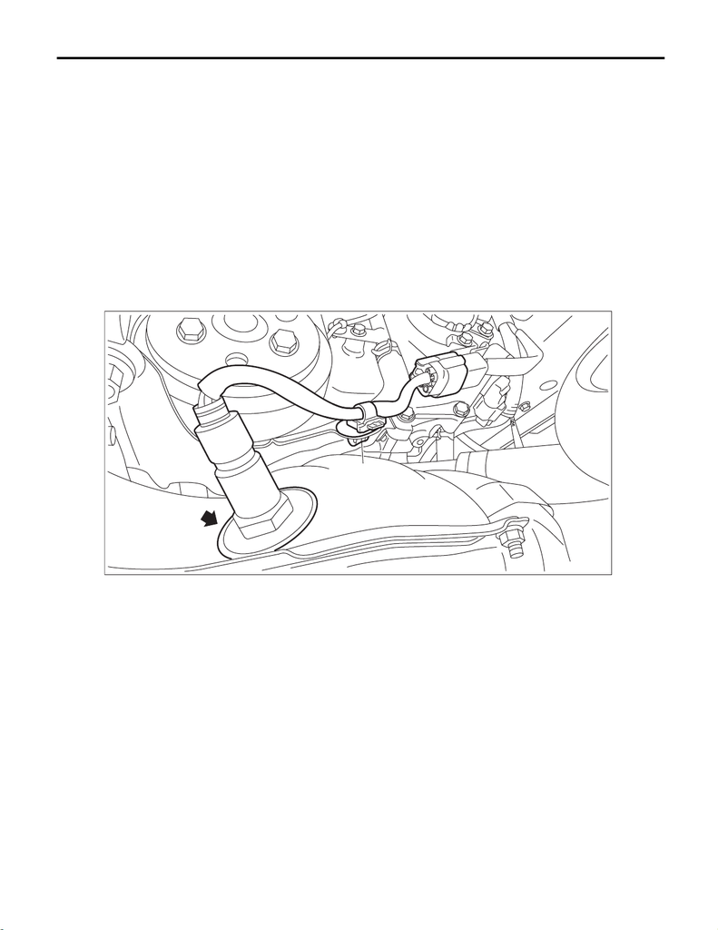

FU(w/o STI)-126

Front Oxygen (A/F) Sensor

FUEL INJECTION (FUEL SYSTEMS)

22.Front Oxygen (A/F) Sensor

A: REMOVAL

1) Disconnect the ground terminal from battery sensor. <Ref. to NT-5, BATTERY, NOTE, Note.>

2) Remove the radiator main fan & fan motor assembly. <Ref. to CO(w/o STI)-46, REMOVAL, Radiator Main

Fan and Fan Motor.>

3) Lift up the vehicle.

4) Remove the under cover. <Ref. to EI-21, REMOVAL, Front Under Cover.>

5) Disconnect the connector (A) on the front oxygen (A/F) sensor from the engine harness, and remove the

clip (B) which secures the front oxygen (A/F) sensor harness to the water pump cover.

6) Apply spray-type lubricant to the threaded portion of front oxygen (A/F) sensor, and leave it for one minute

or more.

7) Remove the front oxygen (A/F) sensor.

CAUTION:

When removing the front oxygen (A/F) sensor, wait until exhaust pipe cools, otherwise it will damage

the exhaust pipe.

B: INSTALLATION

CAUTION:

If lubricant is spilt over the exhaust pipe, wipe it off with cloth to avoid emission of smoke or causing

a fire.

1) Before installing front oxygen (A/F) sensor, apply anti-seize compound only to the threaded portion of front

oxygen (A/F) sensor to make the next removal easier.

CAUTION:

Never apply anti-seize compound to the protector of front oxygen (A/F) sensor.

Anti-seize compound:

NEVER-SEEZ NSN, JET LUBE SS-30 or equivalent

2) Install the front oxygen (A/F) sensor.

Tightening torque:

21 N·m (2.1 kgf-m, 15.5 ft-lb)

(B)

(A)

FU-08374

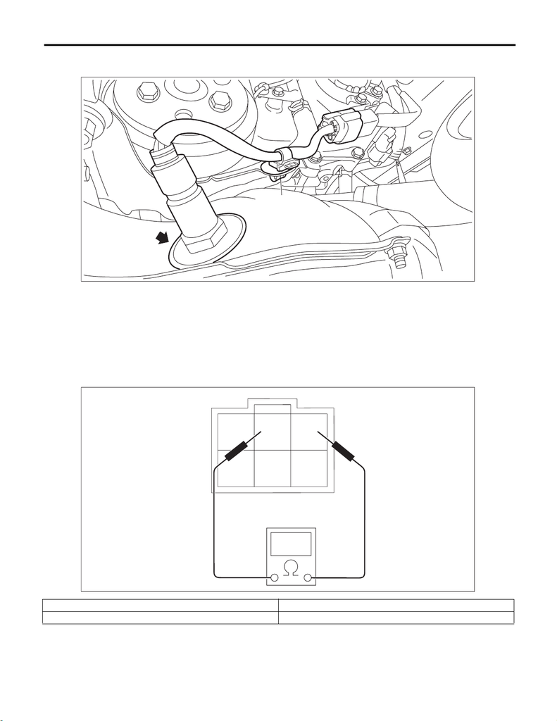

FU(w/o STI)-127

Front Oxygen (A/F) Sensor

FUEL INJECTION (FUEL SYSTEMS)

3) Secure the front oxygen (A/F) sensor harness to the water pump cover using clip (B), and connect the front

oxygen (A/F) sensor connector (A) to the engine harness.

4) Install the under cover. <Ref. to EI-22, INSTALLATION, Front Under Cover.>

5) Lower the vehicle.

6) Install the radiator main fan & fan motor assembly. <Ref. to CO(w/o STI)-46, INSTALLATION, Radiator

Main Fan and Fan Motor.>

7) Connect the ground terminal to battery sensor. <Ref. to NT-5, BATTERY, NOTE, Note.>

C: INSPECTION

1) Check that the front oxygen (A/F) sensor has no deformation, cracks or other damages.

2) Measure the resistance between front oxygen (A/F) sensor terminals.

(B)

(A)

FU-08374

Terminal No. Standard

2 and 3 2.5 — 4.0 Ω (when 20°C (68°F))

13

456

2

FU-08884